# PHL: Weights, Population, Labor Force Participation Checks and Methodology

## Introduction

This document outlines the methods for calculating the final weights used the in GLD survey and reproduces steps – along with outputs – to check that GLD figures align with those published by the Philippine Statistics Authority (PSA).

Survey weights, expanded population, and labor force participation are all fundamental concepts to the GLD that are inextricably linked: quality handling of the weight variable will help ensure that the final survey will generate accurate measurements of the country’s population and labor force figures of that year. This document is indented to provide users with a step-by-step walkthrough of how we analyzed, calculated, and checked these three figures. Since we use a script-based approach instead of a notebook-based approach, this code is an adapted version of population_lfp.R.

### External Sources

All PSA figures have been referred to at either:

- the main Labor Force Survey page: https://psa.gov.ph/statistics/survey/labor-and-employment/labor-force-survey
- or the ILO Comparison Annex file, (direct link): https://psa.gov.ph/sites/default/files/attachments/hsd/pressrelease/Table%2057%20Philipine%20Concept%20vs.%20ILO%20Concept.pdf

## Data Work

### Weights

#### Import the GLD Data

We load tidyverse and the previously appended GLD output data for all survey years, 1997 - 2019.

#### Determine which years and rounds need adjustment

It turns out that not all of the weight variables are uniform in how they scale the data by year or wave, even though the correct weight variable was selected. This could throw off our results. So some scaling will need to be done. Let’s take a look.

```r
sum.w.a <- phl %>%
  group_by(year, wave) %>%
  summarise(weight_median = median(weight, na.rm = TRUE),
            weight_mean   = mean(weight, na.rm = TRUE))

sum.w.a %>% print(n=Inf)
```

```
## # A tibble: 80 x 4
## # Groups:   year [23]
##     year wave  weight_median weight_mean
##    <dbl> <chr>         <dbl>       <dbl>
##  1  1997 Q1         714533.      872344.
##  2  1997 Q2         746544.      898987.
##  3  1997 Q3         675224.      836715.
##  4  1997 Q4         704918.      858926.
##  5  1998 Q1        2885241      3483655.
##  6  1999 Q1        3008107      3680444.
##  7  2000 Q1        3215002      3862953.
##  8  2001 Q1        3119340      3717869.
##  9  2002 Q1         802173       976741.
## 10  2002 Q2         816332.      988550.
## 11  2002 Q3         830892.     1014162.
```

[output cut: 69 more lines]

#### Adjust the weights accordingly

From working with the Philippines LFS data, we know that scaling down these “high” weights by 10,000 typically puts the higher-valued weights in line with the other weight values. Let’s scale the appropriate years and waves, then check.

Also, we’ll create `partic` , a binary indicator for labor force participation. We’ll create it from the GLD variable `lstatus`: a categorical variable that takes three non-missing values. In our case, any non-missing value but `3` / `"Non-Labor Force"` will be coded as `partic == TRUE` . Then, `3` / `"Non-Labor Force"` will be coded as `partic == FALSE` . In the case of the Philippines, `lstatus` is coded directly from variable data provided by the PSA; when available in the survey, we always use the ILO definition of employment status.

#### Update the weights summary object

Now that we have `weight2` in our new `phl2` object that’s adjusted, tentatively, let’s add a by-quarter summary of this new weight variable and add it to the `sum.w.a`.

```r
# create `weight_corrected` vector
weight.adj <- phl2 %>%
  group_by(year, wave) %>%
  summarise(weight_median_corrected = round(median(weight2, na.rm = TRUE)),
            weight_mean_corrected   = round(mean(weight2, na.rm = TRUE)))

weight.adj %>% print(n=Inf)
```

```
## # A tibble: 80 x 4
## # Groups:   year [23]
##     year wave  weight_median_corrected weight_mean_corrected
##    <dbl> <chr>                   <dbl>                 <dbl>
##  1  1997 Q1                         71                    87
##  2  1997 Q2                         75                    90
##  3  1997 Q3                         68                    84
##  4  1997 Q4                         70                    86
##  5  1998 Q1                        289                   348
##  6  1999 Q1                        301                   368
##  7  2000 Q1                        322                   386
##  8  2001 Q1                        312                   372
##  9  2002 Q1                         80                    98
## 10  2002 Q2                         82                    99
## 11  2002 Q3                         83                   101
```

[output cut: 69 more lines]

```r
# join to original weight summary object
sum.w <- sum.w.a %>%
  left_join(weight.adj, by = c("year", "wave")) %>%
  mutate(weight_median_corrected = weight_median_corrected,
         weight_mean_corrected   = weight_mean_corrected)

sum.w %>% print(n=Inf)
```

```
## # A tibble: 80 x 6
## # Groups:   year [23]
##     year wave  weight_median weight_mean weight_median_corre~ weight_mean_corre~
##    <dbl> <chr>         <dbl>       <dbl>                <dbl>              <dbl>
##  1  1997 Q1         714533.      872344.                   71                 87
##  2  1997 Q2         746544.      898987.                   75                 90
##  3  1997 Q3         675224.      836715.                   68                 84
##  4  1997 Q4         704918.      858926.                   70                 86
##  5  1998 Q1        2885241      3483655.                  289                348
##  6  1999 Q1        3008107      3680444.                  301                368
##  7  2000 Q1        3215002      3862953.                  322                386
##  8  2001 Q1        3119340      3717869.                  312                372
##  9  2002 Q1         802173       976741.                   80                 98
## 10  2002 Q2         816332.      988550.                   82                 99
## 11  2002 Q3         830892.     1014162.                   83                101
```

[output cut: 69 more lines]

Looks good. The scaling by `10,000` seemed to bring the weight variables in line – and we appeared to code the correct years and waves. Let’s move on to check our Population and Labor Force Participation Figures with `weight2`

### Checks: Population and LFP

#### Total vs. age 15 and above

We could use the total population, but the PSA provides their figures for ages 15 and above. So we’ll make two versions, just in case.

```r
# Whole population
sum.y <- phl2 %>%
  group_by(year) %>%
  summarize(
    pop = sum(weight2),
    lfp = weighted.mean(partic, weight2, na.rm = TRUE) * 100)

sum.y %>% print(n=Inf)
```

```
## # A tibble: 23 x 3
##     year        pop   lfp
##    <dbl>      <dbl> <dbl>
##  1  1997  71346084.  64.7
##  2  1998  72342618.  63.5
##  3  1999  73940846.  63.9
##  4  2000  75541208.  63.7
##  5  2001  77128303.  65.5
##  6  2002  79302645.  67.4
##  7  2003  80881677.  66.7
##  8  2004  83118917.  64.3
##  9  2005  84781208.  64.3
## 10  2006  85601059.  64.3
## 11  2007  88483701.  64.0
## 12  2008  90237398.  63.6
## 13  2009  92003397.  64.0
## 14  2010  93790610.  64.1
## 15  2011  95582024.  64.6
## 16  2012  97374930.  64.2
## 17  2013  99165399.  63.9
## 18  2014  98193299.  64.4
## 19  2015 101685191.  63.6
## 20  2016 103396610.  63.4
## 21  2017 104713546.  61.2
## 22  2018 106391870.  60.9
## 23  2019 108067302.  61.3
```

Note that we filter out all observations below the age of 15 for the second object.

```r
# for those 15 and over (inclusive)
sum.15.y <- phl2 %>%
  filter(age >= 15) %>%
  group_by(year) %>%
  summarize(
    pop_15up = sum(weight2),
    lfp_15up = weighted.mean(partic, weight2, na.rm = TRUE) * 100)

sum.15.y %>% print(n=Inf)
```

```
## # A tibble: 23 x 3
##     year  pop_15up lfp_15up
##    <dbl>     <dbl>    <dbl>
##  1  1997 44657685.     64.7
##  2  1998 45472389.     63.5
##  3  1999 46779194.     63.9
##  4  2000 48087732.     63.7
##  5  2001 49445862.     65.5
##  6  2002 51392523.     67.4
##  7  2003 52805970.     66.7
##  8  2004 53864675.     64.3
##  9  2005 55287448.     64.3
## 10  2006 57028140.     64.3
## 11  2007 58103202.     64.0
## 12  2008 59602962.     63.6
## 13  2009 61121339.     64.0
## 14  2010 62663795.     64.1
## 15  2011 63900850.     64.6
## 16  2012 65094326.     64.2
## 17  2013 66301441.     63.9
## 18  2014 65691550.     64.4
## 19  2015 67994611.     63.6
## 20  2016 70409982.     63.4
## 21  2017 72131297.     61.2
## 22  2018 73604298.     60.9
## 23  2019 75080712.     61.3
```

#### Adding PSA figures

The PSA data, linked above, we’ll add simply by input in R. It’s not ideal, but it is reproducible should we find an error or point of contention later on. This will allow us to compare the GLD figures for population and labor force participation with those from the PSA.

On the PSA figures themselves, the PSA appear to publish yearly summaries consistently after 2007, but only quarterly before. When the PSA do publish a yearly figure, that figure is used. However, when only quarterly figures are available, we aproximate the yearly figures via a simple mean, recognizing that this is a just an estimation exercise. For those following along with the PSA data, you’ll notice the figures are in reverse chronological order: years are descending and likewise within-year figures read in reverse order. Visually the pattern follows

```r
# year == "2016" ~ [year],
# year == "2015" ~ mean(c([Q4], [Q3], [Q2], [Q1])),
```

```r
sum.15.y <- sum.15.y %>%
  mutate(
    psa_lfp_15up = case_when(
      year == "2019" ~ 61.3,
      year == "2018" ~ 60.9,
      year == "2017" ~ 61.2,
      year == "2016" ~ 63.4,
      year == "2015" ~ mean(c(63.3, 62.9, 64.6, 63.8)),
      year == "2014" ~ 64.4,
      year == "2013" ~ 63.9,
      year == "2012" ~ 64.2,
      year == "2011" ~ 64.6,
      year == "2010" ~ 64.1,
      year == "2009" ~ 64.0,
      year == "2008" ~ 63.6,
      year == "2007" ~ mean(c(63.2, 63.6, 64.5, 64.8)),
      year == "2006" ~ mean(c(63.8, 64.6, 64.8, 63.6)),
      year == "2005" ~ mean(c(64.8, 64.6, 64.8, 63.2)),
      year == "2004" ~ mean(c(63.8, 64.1, 65.4, 64.1)),
      year == "2003" ~ mean(c(64.5, 63.5, 64.0, 63.3)),
      year == "2002" ~ mean(c(63.9, 64.4, 66.3, 64.3)),
      year == "2001" ~ mean(c(62.6)), #only use Q1
      year == "2000" ~ mean(c(62.7)), #only use Q1
      year == "1999" ~ mean(c(63.1)), #only use Q1
      year == "1998" ~ mean(c(62.7)), #only use Q1
      year == "1997" ~ mean(c(63.1, 63.2, 65.5, 63.3))
    ),
    psa_pop_15up = case_when(
      year == "2019" ~ 72931000,
      year == "2018" ~ 71339000,
      year == "2017" ~ 69896000,
      year == "2016" ~ 68125000,
      year == "2015" ~ 66622000,
      year == "2014" ~ 62189000,
      year == "2013" ~ 61176000,
      year == "2012" ~ 62985000,
      year == "2011" ~ 61882000,
      year == "2010" ~ 60717000,
      year == "2009" ~ 59237000,
      year == "2008" ~ 57848000,
      year == "2007" ~ 56864000,
      year == "2006" ~ 55638000,
      year == "2005" ~ 54797000,
      year == "2004" ~ 53562000,
      year == "2003" ~ 52305000,
      year == "2002" ~ 50841000,
      year == "2001" ~ 48413000, #Q1 population data
      year == "2000" ~ 47185000, #Q1 population data
      year == "1999" ~ 45852000, #Q1 population data
      year == "1998" ~ 44517000, #Q1 population data
      year == "1997" ~ 44143000
    ),
    dif_pop_15up = pop_15up - psa_pop_15up,
    dif_lfp_15up = lfp_15up - psa_lfp_15up,
    err_pop_15up = (dif_pop_15up/pop_15up),
    err_lfp_15up = (dif_lfp_15up/lfp_15up),
    flag_pop_5pct= (err_pop_15up >= 0.05),
    flag_lfp_2pct= (err_lfp_15up >= 0.05)
  )
```

#### Final Notes

We see that our scaling method has produced a weight variable, `weight2` that generates population and labor force figures that are very consistent with those published by the PSA. All but two, or 21 of 23 years, pass our self-imposed consistency tests. Even so, the data for these two years that do not pass are still within reasonable margins of error. What is more, labor force participation rate for these same years appears to be nearly identical with the PSA figures. The case of years 2013-2014 and the summary data as a whole suggest that any issues with the weight variable are likely reflected in final measurements of magnitude and more than ratios.

### Graphs

We can visualize our final results below. The graphical results reiterate the finding that the differences between the population figures of GLD and those from the PSA do not reflect discrepancies in measurements of labor force participation.

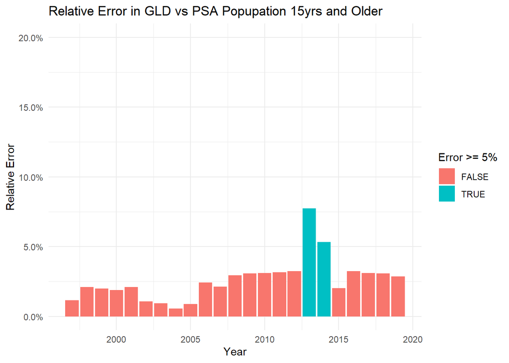

```r
gg.pop <- ggplot(sum.15.y, aes(year, err_pop_15up)) +
  geom_col(aes(fill = flag_pop_5pct)) +
  scale_y_continuous(labels = scales::label_percent(), limits = c(0,0.2)) +
  labs(title = "Relative Error in GLD vs PSA Popupation 15yrs and Older",
       y = "Relative Error",
       x = "Year",
       fill= "Error >= 5%") +
  theme_minimal()

gg.pop
```

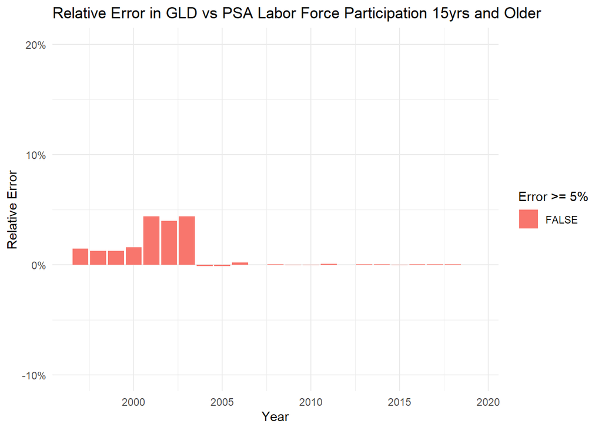

```r
gg.lfp <- ggplot(sum.15.y, aes(year, err_lfp_15up)) +
  geom_col(aes(fill = flag_lfp_2pct)) +
  scale_y_continuous(labels = scales::label_percent(), limits = c(-0.1, 0.2)) +
  labs(title = "Relative Error in GLD vs PSA Labor Force Participation 15yrs and Older",
       y = "Relative Error",
       x = "Year",
       fill= "Error >= 5%") +
  theme_minimal()

gg.lfp
```